# Case Study 1

Allen Ansari,Audrene Tiakor

February 17, 2019

```r
library(ggplot2) # Data visualization
library(readr) # CSV file I/O, e.g. the read_csv function
library(dplyr) # Heavy use of this library
library(tidyr)
library(plyr)
library(ggthemes) # for themes in ggplot
library(knitr)
library(kableExtra) # library to make the document more presentable
library(Amelia) # for missing map
library(datasets) # to make region col
library(zoo)
library(agricolae)
library(naniar)
```

```r
# Read in beer and breweries data set using _csv for more tidy output
Beers <- read_csv('Beers.csv', col_types = cols())
Breweries <- read_csv('Breweries.csv', col_types = cols())
```

### 1. How many breweries are present in each state?

To answer this question we used table function to retrieve the value of `State` from the `Breweries` data.

```r
BrewPerState <-table(Breweries$State)
BrewPerState
```

```
##
## AK AL AR AZ CA CO CT DC DE FL GA HI IA ID IL IN KS KY LA MA MD ME MI MN MO
##  7  3  2 11 39 47  8  1  2 15  7  4  5  5 18 22  3  4  5 23  7  9 32 12  9
## MS MT NC ND NE NH NJ NM NV NY OH OK OR PA RI SC SD TN TX UT VA VT WA WI WV
##  2  9 19  1  5  3  3  4  2 16 15  6 29 25  5  4  1  3 28  4 16 10 23 20  1
## WY
##  4
```

### 2. Merge beer data with the breweries data. Print the first 6 observations and the last six observations to check the merged file.

```r
BrewPub <- merge(Beers, Breweries, by.x = "Brewery_id", by.y = "Brew_ID", all = TRUE)
# Change variable names to more meaningful title

BrewPub <- rename(BrewPub, c("Name.x"="Beer","Name.y"="Brewery",
                   "Ounces"="OZ"))
# Used kable library to make document more presentable
kable(BrewPub %>%
         head()) %>%
         kable_styling("striped", full_width = F)
```

| Brewery_id | Beer | Beer_ID | ABV | IBU | Style | OZ | Brewery | City | State |
| --- | --- | --- | --- | --- | --- | --- | --- | --- | --- |
| 1 | Get Together | 2692 | 0.045 | 50 | American IPA | 16 | NorthGate Brewing | Minneapolis | MN |
| 1 | Maggie’s Leap | 2691 | 0.049 | 26 | Milk / Sweet Stout | 16 | NorthGate Brewing | Minneapolis | MN |
| 1 | Wall’s End | 2690 | 0.048 | 19 | English Brown Ale | 16 | NorthGate Brewing | Minneapolis | MN |
| 1 | Pumpion | 2689 | 0.060 | 38 | Pumpkin Ale | 16 | NorthGate Brewing | Minneapolis | MN |
| 1 | Stronghold | 2688 | 0.060 | 25 | American Porter | 16 | NorthGate Brewing | Minneapolis | MN |
| 1 | Parapet ESB | 2687 | 0.056 | 47 | Extra Special / Strong Bitter (ESB) | 16 | NorthGate Brewing | Minneapolis | MN |

```r
kable(BrewPub %>%
         tail()) %>%
         kable_styling("striped", full_width = F)
```

|  | Brewery_id | Beer | Beer_ID | ABV | IBU | Style | OZ | Brewery | City | State |
| --- | --- | --- | --- | --- | --- | --- | --- | --- | --- | --- |
| 2405 | 556 | Pilsner Ukiah | 98 | 0.055 | NA | German Pilsener | 12 | Ukiah Brewing Company | Ukiah | CA |
| 2406 | 557 | Heinnieweisse Weissebier | 52 | 0.049 | NA | Hefeweizen | 12 | Butternuts Beer and Ale | Garrattsville | NY |
| 2407 | 557 | Snapperhead IPA | 51 | 0.068 | NA | American IPA | 12 | Butternuts Beer and Ale | Garrattsville | NY |
| 2408 | 557 | Moo Thunder Stout | 50 | 0.049 | NA | Milk / Sweet Stout | 12 | Butternuts Beer and Ale | Garrattsville | NY |
| 2409 | 557 | Porkslap Pale Ale | 49 | 0.043 | NA | American Pale Ale (APA) | 12 | Butternuts Beer and Ale | Garrattsville | NY |
| 2410 | 558 | Urban Wilderness Pale Ale | 30 | 0.049 | NA | English Pale Ale | 12 | Sleeping Lady Brewing Company | Anchorage | AK |

### 3. Report the number of NA’s in each column.

To do this, we use a function (which returns `true` if a given value is NA, `false` otherwise, using `is.na`) and `sapply` to determine the number of missing values for each column within `BrewPub`.

Per the results, we find that there are a total of 62 ABV values missing, 1005 IBU values amd 5 Style values missing. No other data is missing.

```r
MissingValues <- sapply(BrewPub,function(MissingValue)sum(is.na(MissingValue)))

# Used kable library to make document more presentable
as.data.frame(MissingValues) %>%
  kable("html") %>%
  kable_styling("striped", full_width = F)
```

|  | MissingValues |
| --- | --- |
| Brewery_id | 0 |
| Beer | 0 |
| Beer_ID | 0 |
| ABV | 62 |
| IBU | 1005 |
| Style | 5 |
| OZ | 0 |
| Brewery | 0 |
| City | 0 |
| State | 0 |

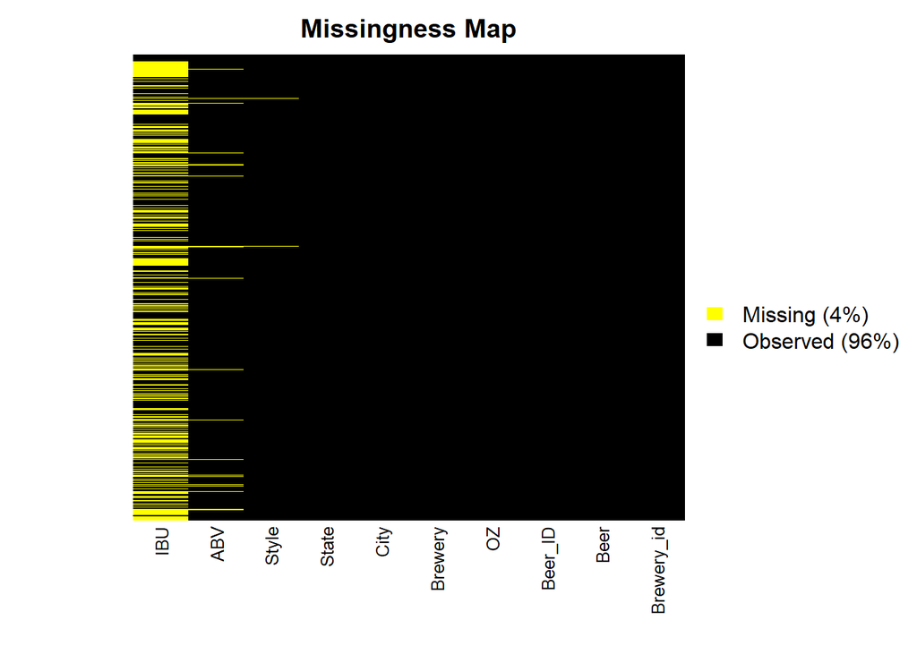

```r
missmap(BrewPub,y.at=c(1),y.labels = c(''),col=c('yellow','black'))
```

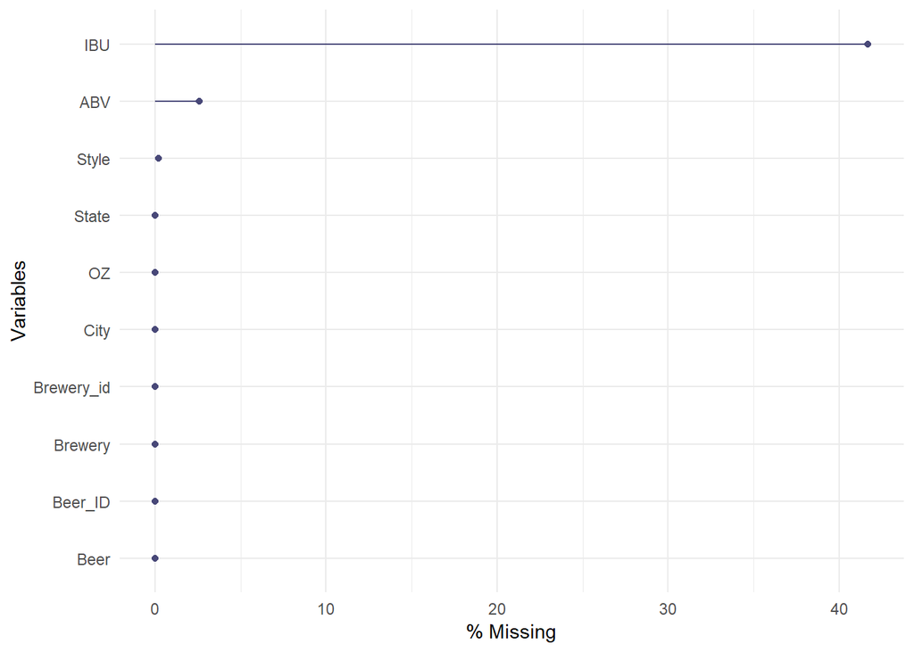

```r
# Below plot shows more than 40% of IBU and 3% of ABV are missing
gg_miss_var(BrewPub, show_pct = TRUE)
```

### 4. Compute the median alcohol content and international bitterness unit for each state. Plot a bar chart to compare.

```r
# 4.a Compute the median alcohol content unit for each state.
Alc <- BrewPub %>%
  na.omit()  %>%
group_by(State) %>%
summarise_each(funs(median), Median_ABV = ABV) %>%
arrange(Median_ABV)
```

```
## `summarise_each()` is deprecated.
## Use `summarise_all()`, `summarise_at()` or `summarise_if()` instead.
## To map `funs` over a selection of variables, use `summarise_at()`
```

```r
Alc
```

```
## # A tibble: 50 x 2
##    State Median_ABV
##    <chr>      <dbl>
##  1 AR        0.04
##  2 UT        0.04
##  3 NJ        0.046
##  4 NH        0.0465
##  5 KS        0.05
##  6 MO        0.05
##  7 ND        0.05
##  8 SC        0.05
##  9 WI        0.051
## 10 LA        0.051
## # ... with 40 more rows
```

```r
# 4. b Compute the median international bitterness unit for each state.
Bitter <- BrewPub %>%
  na.omit() %>%
group_by(State) %>%
summarise_each(funs(median), Median_IBU = IBU) %>%
arrange(Median_IBU)
```

```
## `summarise_each()` is deprecated.
## Use `summarise_all()`, `summarise_at()` or `summarise_if()` instead.
## To map `funs` over a selection of variables, use `summarise_at()`
```

```r
Bitter
```

```
## # A tibble: 50 x 2
##    State Median_IBU
##    <chr>      <dbl>
##  1 WI          19
##  2 AZ          20
##  3 KS          20
##  4 WY          21
##  5 HI          22.5
##  6 MO          24
##  7 RI          24
##  8 IA          26
##  9 CT          29
## 10 MD          29
## # ... with 40 more rows
```

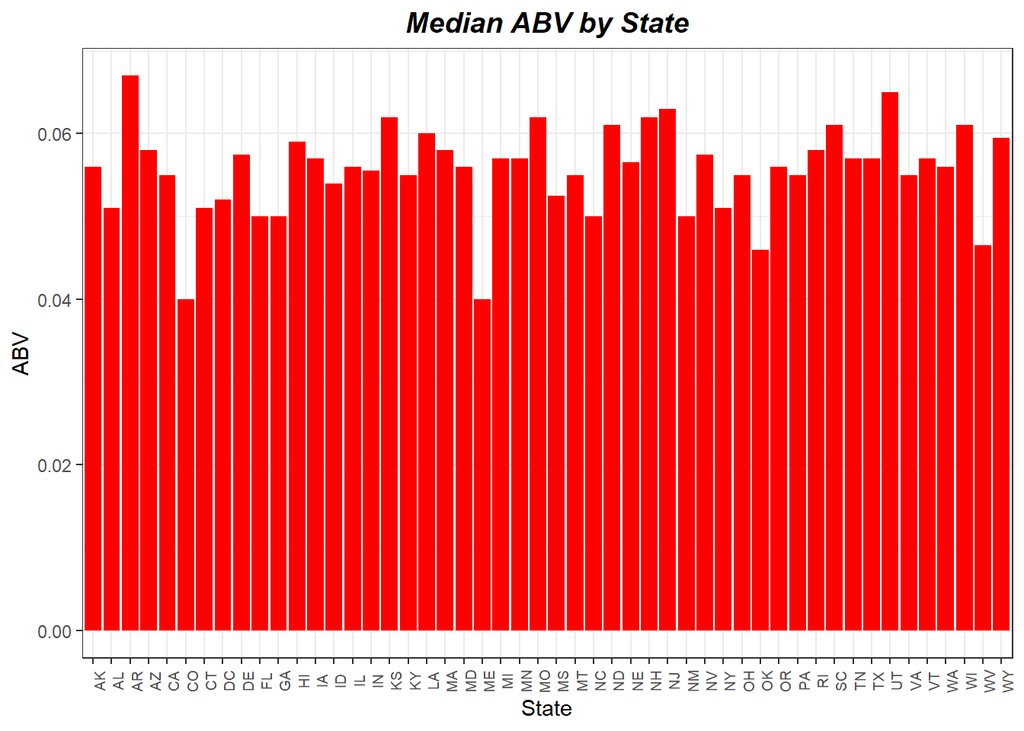

```r
# 4. c Plot a bar chart to compare ABV by state

ggplot(data=Alc, aes(x=State, y=sort(Median_ABV,decreasing = TRUE))) +
  geom_bar(stat="identity", fill="red")+
  theme_bw() +
  scale_color_economist()+
  theme(axis.text.x=element_text(size=rel(0.8), angle=90),plot.title = element_text(size=14,hjust = 0.5, face="bold.italic")) +
  ggtitle("Median ABV by State") +
  labs(x="State",y="ABV")
```

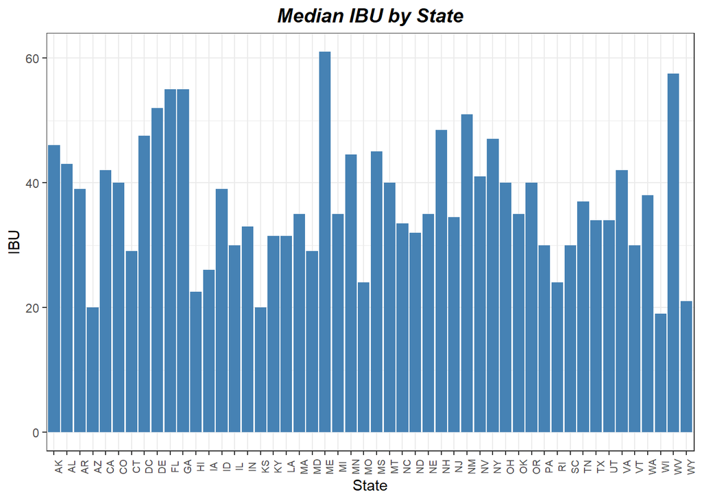

```r
# 4. d Plot a bar chart to compare IBU by state
ggplot(data=Bitter, aes(x=State, y=Median_IBU)) +
  geom_bar(stat="identity", fill="steelblue")+
  theme_bw() +
  scale_color_economist()+
  theme(axis.text.x=element_text(size=7, angle=90),plot.title = element_text(size=14,hjust = 0.5, face="bold.italic"))+ ggtitle("Median IBU by State") + labs(x="State",y="IBU")
```

## 5- Which state has the maximum alcoholic (ABV) beer? Which state has the most bitter (IBU) beer?

```r
# finding state which has has the maximum alcoholic (ABV) beer
Max_ABV <- BrewPub[which.max(BrewPub$ABV),]
Max_ABV
```

```
##     Brewery_id                                                 Beer
## 375         52 Lee Hill Series Vol. 5 - Belgian Style Quadrupel Ale
##     Beer_ID   ABV IBU            Style   OZ                 Brewery
## 375    2565 0.128  NA Quadrupel (Quad) 19.2 Upslope Brewing Company
##        City State
## 375 Boulder    CO
```

```r
# finding state which has has the maximum alcoholic (IBU) beer
Max_IBU <- BrewPub[which.max(BrewPub$IBU),]
Max_IBU
```

```
##      Brewery_id                      Beer Beer_ID   ABV IBU
## 1857        375 Bitter Bitch Imperial IPA     980 0.082 138
##                               Style OZ                 Brewery    City
## 1857 American Double / Imperial IPA 12 Astoria Brewing Company Astoria
##      State
## 1857    OR
```

## 6- Summary statistics for the ABV variable

To do this, we apply the function summary() to the variable ABV (alcohol content of our data set ‘BrewPub’), which returns descriptive statistics of ABV such as the minimum value (smallest value of ABV), the first quartile, the median, the mean, the thrid quartile, and the maximum (largest value of ABV).

```r
# summary statistics for the ABV variable
summary(BrewPub$ABV)
```

```
##    Min. 1st Qu.  Median    Mean 3rd Qu.    Max.    NA's
## 0.00100 0.05000 0.05600 0.05977 0.06700 0.12800      62
```

## 7- Is there an apparent relationship between the bitterness of the beer and its alcoholic content?

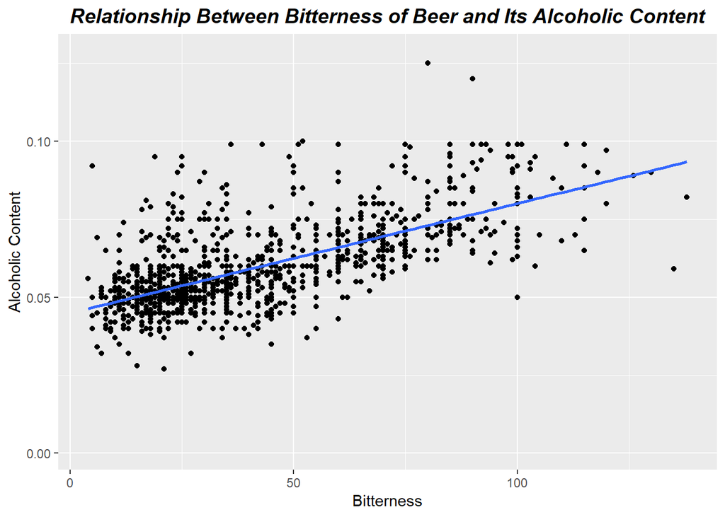

```r
# drawing a Scatter plot Bitterness of Beer vs Alcholic content
ggplot(BrewPub, aes(x=BrewPub$IBU, y=BrewPub$ABV)) + geom_point() + geom_smooth(method=lm, se=FALSE) + theme(plot.title = element_text(size=14,hjust= 0.5, face="bold.italic")) + ggtitle("Relationship Between Bitterness of Beer and Its Alcoholic Content") +
  labs(x="Bitterness",y="Alcoholic Content")
```

After plotting a scatter plot to depict the relationship between the bitterness of the beer and its alcoholic content, we can see that there is a positive correlation between the bitterness of the beer and its alcoholic content. The higher the alcohol content, the more bitter the beer will taste. With this information an ANOVA for the relationship between IBU and ABV can be conducted. If we can conclude that this model is significant, then a linear regression model can be found with its respective linear regression equation to quanitfy the relationship between IBU and ABV, also enabling the option to predict ABV for IBU that we don’t have but would like to explore.

### Regression Line for relationship between IBU and ABV

```r
# Compute ANOVA for ABV and IBU
reg1 <- lm(ABV ~ IBU , data = BrewPub)
# Summary of reg 1
summary(reg1)
```

```
##
## Call:
## lm(formula = ABV ~ IBU, data = BrewPub)
##
## Residuals:
##       Min        1Q    Median        3Q       Max
## -0.033288 -0.005946 -0.001595  0.004022  0.052006
##
## Coefficients:
##              Estimate Std. Error t value Pr(>|t|)
## (Intercept) 4.493e-02  5.177e-04   86.79   <2e-16 ***
## IBU         3.508e-04  1.036e-05   33.86   <2e-16 ***
## ---
## Signif. codes:  0 '***' 0.001 '**' 0.01 '*' 0.05 '.' 0.1 ' ' 1
##
## Residual standard error: 0.01007 on 1403 degrees of freedom
##   (1005 observations deleted due to missingness)
## Multiple R-squared:  0.4497, Adjusted R-squared:  0.4493
## F-statistic:  1147 on 1 and 1403 DF,  p-value: < 2.2e-16
```

Here we have a p-value of 2e^-16, so at the alpha= 0.05 level we find that there is strong evidence that there is a relationship between IBU and ABV. To quantify this relationship, a linear regression model will be graphed, with its respective equation.

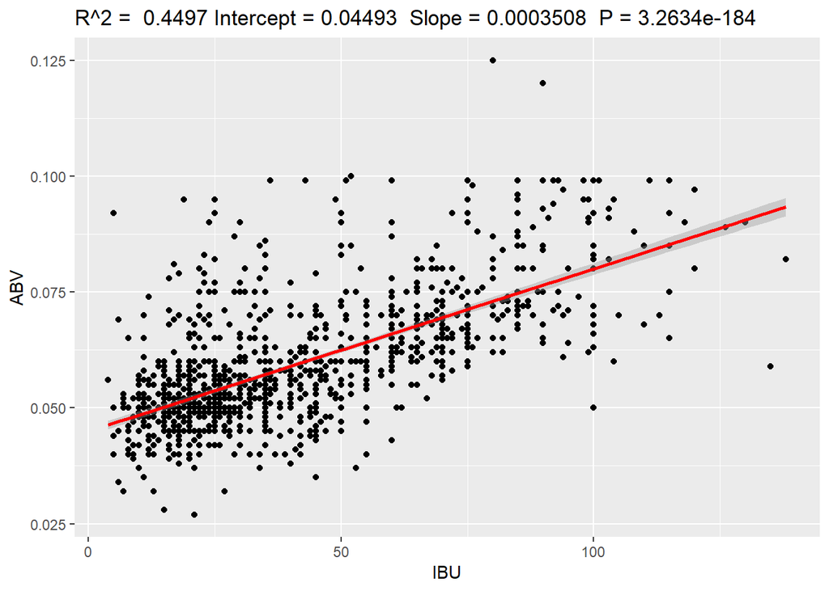

```r
# Create a function to pull the data out of a linear regression, return values such as  (R-squares, slope, intercept and P value) at the top of a nice ggplot graph with the regression line.
Regressionplot <- function (reg) {

require(ggplot2)

 ggplot(reg$model, aes_string(x = names(reg$model)[2], y = names(reg$model)[1])) + geom_point() + stat_smooth(method = "lm", col = "red") + labs(title = paste("R^2 = ",signif(summary(reg)$r.squared, 4), "Intercept =",signif(reg$coef[[1]],5 ), " Slope =",signif(reg$coef[[2]], 5), " P =",signif(summary(reg)$coef[2,4], 5)))
}

#Final regression plot with R^2 adj, intercept/slope of linear regression line, and p-value
Regressionplot(reg1)
```

## Further Analysis of Data (By Region)

After using the visual evidence of the scatter plot of the relationship between IBU and ACV, further analysis was used to look at the IBU and ACV of regions. The states were taken and split into the following regions: South, West, Northeast, and North Central . After each state was separated into their respective regions, Explanatory Data Analysis and ANOVA was used to see if there was any significant results between IBU and ACV of each region.

After plotting a scatter plot to depict the relationship between the bitterness of the beer and its alcoholic content, we can see that there is a positive correlation between the bitterness of the beer and its alcoholic content. The higher the alcohol content, the more bitter the beer will taste.

```r
# Creating Region Col
StateAbb <- as.data.frame(state.abb) # usnig stat.abb dataset
StateRegion <- as.data.frame(state.region) # using state.region dataser
# Combinde 2 datasets
State <- cbind(StateAbb,StateRegion)
names(State) <- c("State" , "Region")
# Merge State by BrewPub
BrewRegion <- merge(BrewPub,State, by="State")
```

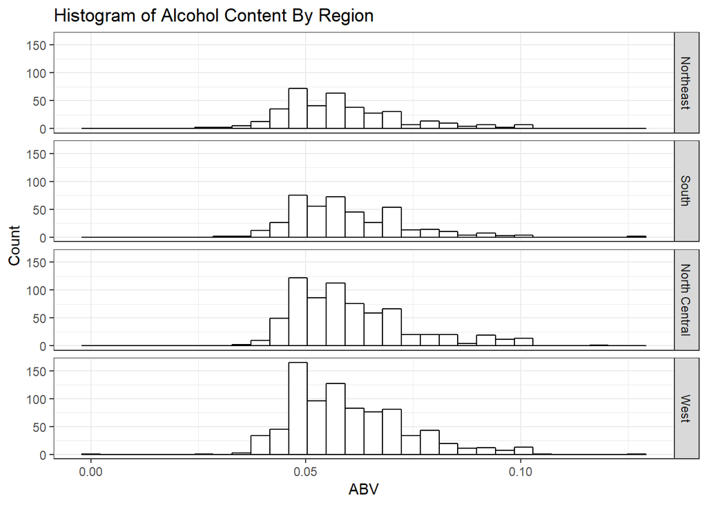

```r
# Histogram of ABV
ABV_Hist <- ggplot(BrewRegion,aes(x=ABV)) + geom_histogram(colour="black", fill="white") +theme(axis.text.x=element_text(size=7), plot.title = element_text(size=14,hjust = 0.5, face="bold.italic")) + theme_bw() + ggtitle("Histogram of Alcohol Content By Region") + labs(x="ABV",y="Count") +  facet_grid(Region ~ .)
ABV_Hist
```

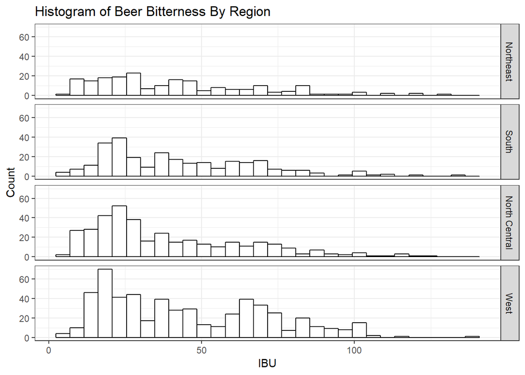

```r
# Histogram of IBU
IBU_Hist <- ggplot(BrewRegion,aes(x=IBU)) + geom_histogram(colour="black", fill="white") +theme(axis.text.x=element_text(size=7), plot.title = element_text(size=14,hjust = 0.5, face="bold.italic")) + theme_bw() + ggtitle("Histogram of Beer Bitterness By Region") + labs(x="IBU",y="Count") + facet_grid(Region ~ .)
IBU_Hist
```

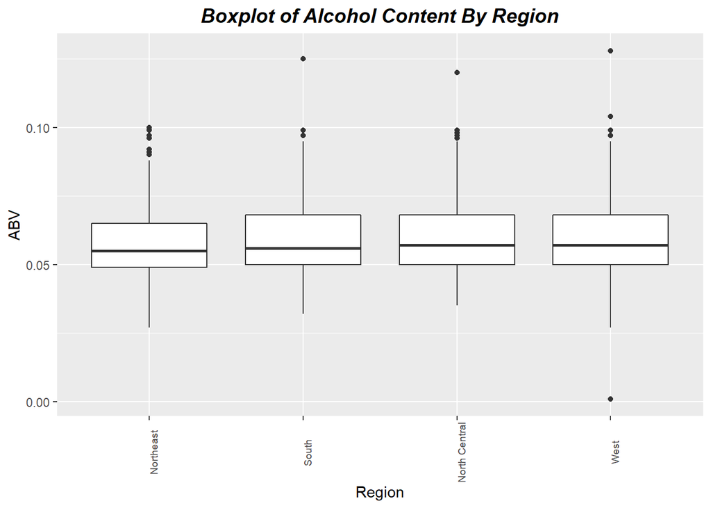

```r
# Boxplot of Alcohol Content By Region
Alch<-ggplot((BrewRegion), aes(x = Region, y = ABV)) + geom_boxplot() + theme(axis.text.x=element_text(size=7, angle=90), plot.title = element_text(size=14,hjust = 0.5, face="bold.italic"))+ ggtitle("Boxplot of Alcohol Content By Region") + labs(x="Region",y="ABV")
Alch
```

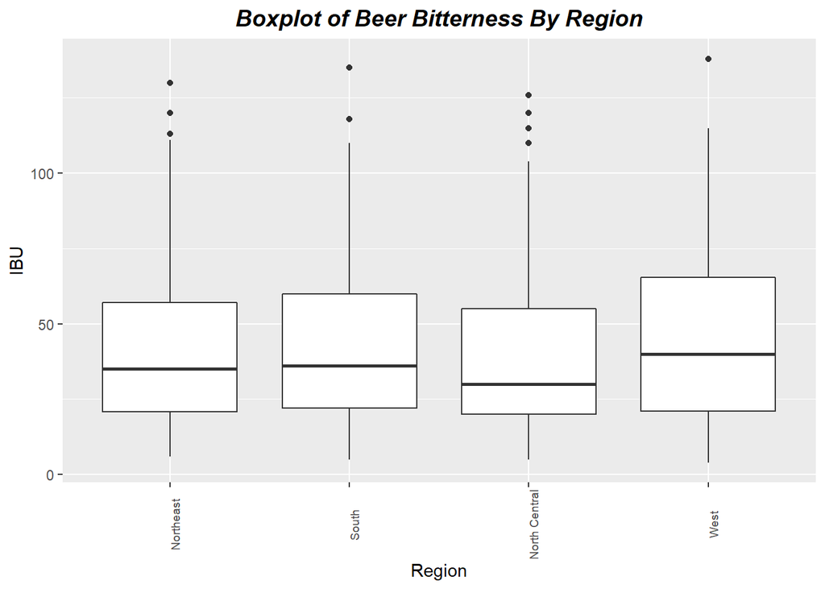

```r
# Boxplot of Beer Bitterness By Region
Bitt<- ggplot((BrewRegion), aes(x = Region, y = IBU)) + geom_boxplot() + theme(axis.text.x=element_text(size=7, angle=90), plot.title = element_text(size=14,hjust = 0.5, face="bold.italic"))+ ggtitle("Boxplot of Beer Bitterness By Region") + labs(x="Region",y="IBU")
Bitt
```

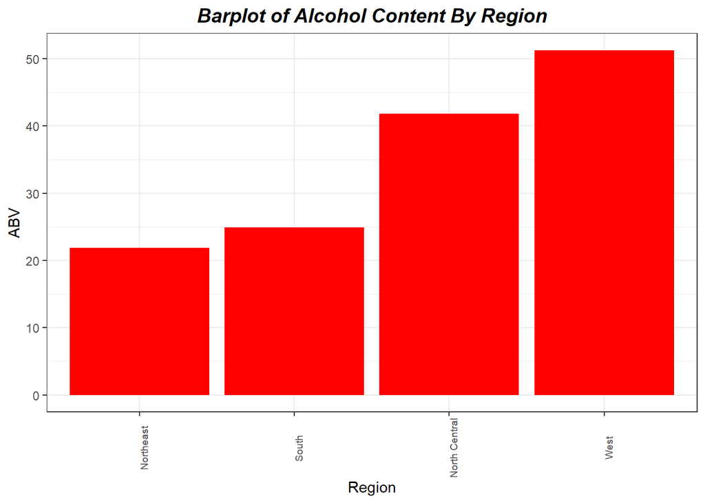

```r
# ABV per Region Bar Plot
ggplot(BrewRegion, aes(x=Region, y=ABV)) +
  geom_bar(stat="identity", fill="red")+
  theme_bw() +
  scale_color_economist()+
  theme(axis.text.x=element_text(size=rel(0.8), angle=90),plot.title = element_text(size=14,hjust = 0.5, face="bold.italic")) + ggtitle("ABV by Region") +


  ggtitle("ABV by Region") +

  ggtitle("Barplot of Alcohol Content By Region") +


  labs(x="Region",y="ABV")
```

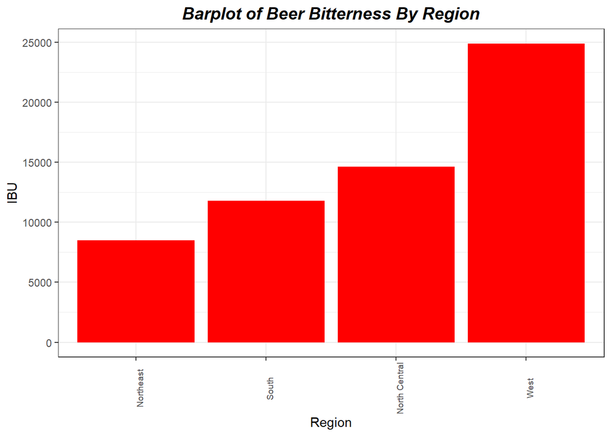

```r
# IBU per Region Bar plot
ggplot(BrewRegion, aes(x=Region, y=IBU)) +
  geom_bar(stat="identity", fill="red")+
  theme_bw() +
  scale_color_economist()+
  theme(axis.text.x=element_text(size=rel(0.8), angle=90),plot.title = element_text(size=14,hjust = 0.5, face="bold.italic")) + ggtitle("Barplot of Beer Bitterness By Region") + labs(x="Region",y="IBU")
```

```
## `summarise_each()` is deprecated.
## Use `summarise_all()`, `summarise_at()` or `summarise_if()` instead.
## To map `funs` over a selection of variables, use `summarise_at()`
```

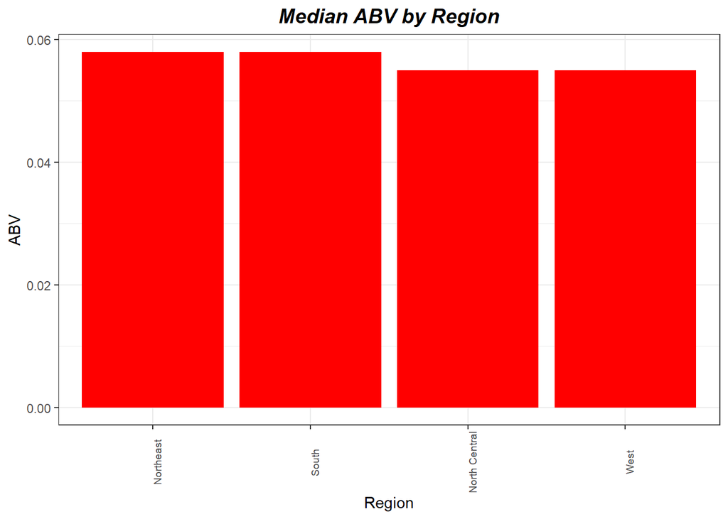

```r
#  Plot a bar chart to compare Median of ABV by Region

BrewRegion %>%   na.omit() %>%
group_by(Region) %>%
summarise_each(funs(median), Median_ABV = ABV) %>% ggplot(aes(x=Region, y=sort(Median_ABV,decreasing = TRUE))) +
  geom_bar(stat="identity", fill="red")+
  theme_bw() +
  scale_color_economist()+
  theme(axis.text.x=element_text(size=rel(0.8), angle=90),plot.title = element_text(size=14,hjust = 0.5, face="bold.italic")) +
  ggtitle("Median ABV by Region") +
  labs(x="Region",y="ABV")
```

```
## `summarise_each()` is deprecated.
## Use `summarise_all()`, `summarise_at()` or `summarise_if()` instead.
## To map `funs` over a selection of variables, use `summarise_at()`
```

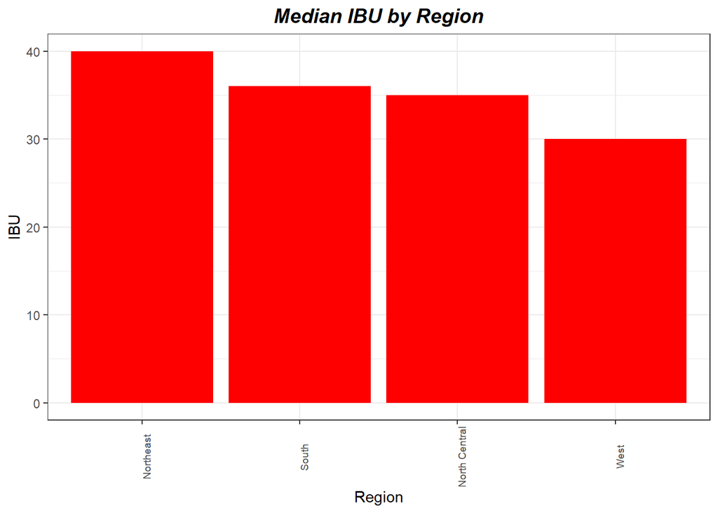

```r
#  Plot a bar chart to compare Median of IBU by Region

BrewRegion %>%   na.omit() %>%
group_by(Region) %>%
summarise_each(funs(median), Median_IBU = IBU) %>% ggplot(aes(x=Region, y=sort(Median_IBU,decreasing = TRUE))) +
  geom_bar(stat="identity", fill="red")+
  theme_bw() +
  scale_color_economist()+
  theme(axis.text.x=element_text(size=rel(0.8), angle=90),plot.title = element_text(size=14,hjust = 0.5, face="bold.italic")) +
  ggtitle("Median IBU by Region") +
  labs(x="Region",y="IBU")
```

### Analysis Of Variance

```r
# Compute the analysis of variance for ABV mean
BeerABV.aov <- aov(ABV ~ Region, data = BrewRegion)
# Summary of the analysis
summary(BeerABV.aov)
```

```
##               Df Sum Sq   Mean Sq F value Pr(>F)
## Region         3 0.0017 0.0005511   3.015 0.0289 *
## Residuals   2336 0.4270 0.0001828
## ---
## Signif. codes:  0 '***' 0.001 '**' 0.01 '*' 0.05 '.' 0.1 ' ' 1
## 62 observations deleted due to missingness
```

```r
# There is strong evidence showing that at confidence level of 0.05 at least the mean of ABV of two region are different (P-Value = 0.02)



# Compute the analysis of variance for IBU mean
BeerIBU.aov <- aov(IBU ~ Region, data = BrewRegion)
# Summary of the analysis
summary(BeerIBU.aov)
```

```
##               Df Sum Sq Mean Sq F value  Pr(>F)
## Region         3   9220  3073.4   4.626 0.00317 **
## Residuals   1397 928142   664.4
## ---
## Signif. codes:  0 '***' 0.001 '**' 0.01 '*' 0.05 '.' 0.1 ' ' 1
## 1001 observations deleted due to missingness
```

```r
# There is strong evidence showing that at confidence level of 0.05 at least the mean of IBU of two region are different (P-Value = 0.0031)
```

## Multiple Comparisons By Region: The Bonferroni Procedure

After performing an ANOVA for IBU and ABV by region and concluding that the betterness and alcohol content differ in beer between regions. To examine which regions differ in regards to IBU and ABV, a multiple comparison procedure is used to find which regions differ. The choice of procedure used for this analysis is the Bonferroni Procedure.

```r
# Bonferroni Procedure to assess which regions differ in IBU
print(LSD.test(aov(lm(IBU ~ Region, data=BrewRegion)), "Region", p.adj=c("bonferroni")))
```

```
## $statistics
##    MSerror   Df     Mean       CV
##   664.3822 1397 42.67737 60.39644
##
## $parameters
##         test  p.ajusted name.t ntr alpha
##   Fisher-LSD bonferroni Region   4  0.05
##
## $means
##                    IBU      std   r      LCL      UCL Min Max   Q25 Q50
## North Central 39.19035 25.30329 373 36.57229 41.80841   5 126 20.00  30
## Northeast     41.57843 26.40083 204 38.03831 45.11855   6 130 20.75  35
## South         42.55957 24.57039 277 39.52153 45.59761   5 135 22.00  36
## West          45.52468 26.44548 547 43.36276 47.68660   4 138 21.00  40
##                Q75
## North Central 55.0
## Northeast     57.0
## South         60.0
## West          65.5
##
## $comparison
## NULL
##
## $groups
##                    IBU groups
## West          45.52468      a
## South         42.55957     ab
## Northeast     41.57843     ab
## North Central 39.19035      b
##
## attr(,"class")
## [1] "group"
```

```r
# Bonferroni Procedure to assess which regions differ in ABV
print(LSD.test(aov(lm(ABV ~ Region, data=BrewRegion)), "Region", p.adj=c("bonferroni")))
```

```
## $statistics
##        MSerror   Df       Mean       CV
##   0.0001827874 2336 0.05975342 22.62613
##
## $parameters
##         test  p.ajusted name.t ntr alpha
##   Fisher-LSD bonferroni Region   4  0.05
##
## $means
##                      ABV        std   r        LCL        UCL   Min   Max
## North Central 0.06056440 0.01366493 691 0.05955583 0.06157297 0.035 0.120
## Northeast     0.05807181 0.01373978 376 0.05670454 0.05943907 0.027 0.100
## South         0.05935084 0.01270642 419 0.05805563 0.06064604 0.032 0.125
## West          0.06003513 0.01369004 854 0.05912790 0.06094236 0.001 0.128
##                 Q25   Q50   Q75
## North Central 0.050 0.057 0.068
## Northeast     0.049 0.055 0.065
## South         0.050 0.056 0.068
## West          0.050 0.057 0.068
##
## $comparison
## NULL
##
## $groups
##                      ABV groups
## North Central 0.06056440      a
## West          0.06003513     ab
## South         0.05935084     ab
## Northeast     0.05807181      b
##
## attr(,"class")
## [1] "group"
```

```r
# Bonferroni Procedure to assess which regions differ in IBU and ABV
print(LSD.test(aov(lm(IBU*ABV ~ Region, data=BrewRegion)), "Region", p.adj=c("bonferroni")))
```

```
## $statistics
##    MSerror   Df    Mean       CV
##   4.931171 1397 2.79101 79.56346
##
## $parameters
##         test  p.ajusted name.t ntr alpha
##   Fisher-LSD bonferroni Region   4  0.05
##
## $means
##               IBU * ABV      std   r      LCL      UCL   Min    Max    Q25
## North Central  2.520311 2.140898 373 2.294760 2.745862 0.250 11.640 1.0880
## Northeast      2.686157 2.265681 204 2.381168 2.991146 0.204 11.700 1.0475
## South          2.791643 2.169852 277 2.529909 3.053376 0.200 10.620 1.1750
## West           3.014384 2.281581 547 2.828130 3.200638 0.224 11.316 1.1600
##                  Q50    Q75
## North Central 1.7500 3.4650
## Northeast     2.0325 3.5910
## South         2.0300 4.0300
## West          2.1750 4.4325
##
## $comparison
## NULL
##
## $groups
##               IBU * ABV groups
## West           3.014384      a
## South          2.791643     ab
## Northeast      2.686157     ab
## North Central  2.520311      b
##
## attr(,"class")
## [1] "group"
```

For the Bonferroni Procedure, if the groups have different letters, then those groups are significantly different. In the context of this study, the regions that have different letters are the regions that are significantly different, in other words, the regions with different letters are the regions whose alcoholic content by volume and international bitterness unit differ. For alcoholic content by volume (ABV), ABV is different in the North Central region and Northeast region. For international bitterness unit (IBU), IBU is different in the West region and North Central region. When comparing IBU and ABV in each region, we find that the IBU and ABV in the West and North Central Region differ.